# Statistical inference with the GSS data

```r
library(ggplot2)
library(dplyr)
library(statsr)
```

```r
load("gss.Rdata")
```

- Non-response bias: If only a non-random fraction of the survey recipients respond

Therefore, this study can only be generalised to the American population and no causality can be concluded

```r
genderJobConfidence <- gss[c("sex","joblose")] %>% filter(!is.na(joblose)) %>% mutate(response = ifelse(joblose == "Very Likely" | joblose == "Fairly Likely","Yes","No")) %>% group_by(sex,response) %>% summarise(count=n())

head(genderJobConfidence)
```

```
## Source: local data frame [4 x 3]
## Groups: sex [2]
##
##      sex response count
##   <fctr>    <chr> <int>
## 1   Male       No  8455
## 2   Male      Yes  1039
## 3 Female       No  8277
## 4 Female      Yes  1001
```

## Research question

Job security is an important factor that provides stability and better opportunities to families. Are males and females equally likely to think that it is *very likely* or *fairly likely* that they will lose their job in the next 12 months?

## Exploratory data analysis

Let’s first understand the yearly distribution of the dataset.

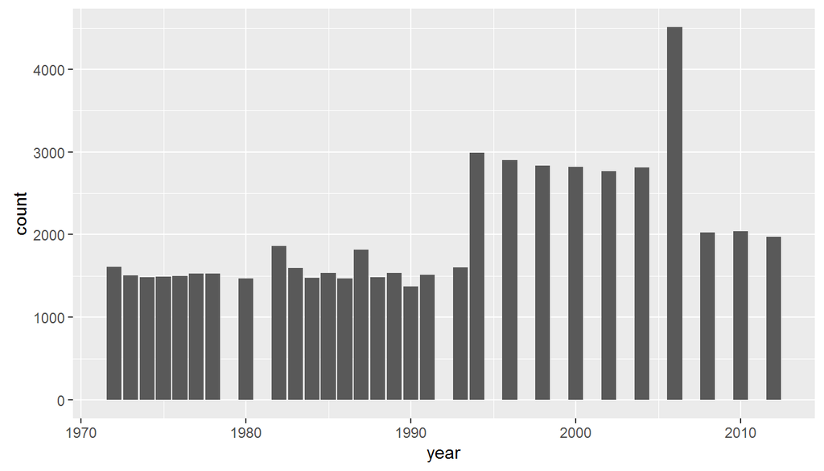

```r
ggplot(gss, aes(x= year)) + geom_bar()
```

As we can see, the survey first started yearly, except for 1979, 1981 and 1992. Since 1994, the GSS has been conducted in even numbered years.

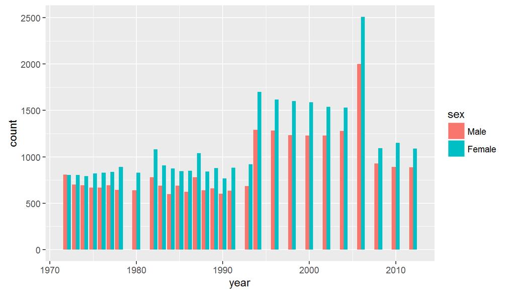

```r
ggplot(gss, aes(x= year, fill=sex)) + geom_bar(position = "dodge")
```

```r
gss_modified <- gss %>% mutate(toAnalyse = ifelse(is.na(joblose),"No","Yes")) %>% mutate(response = ifelse(joblose == "Very Likely" | joblose == "Fairly Likely","Yes","No"))
```

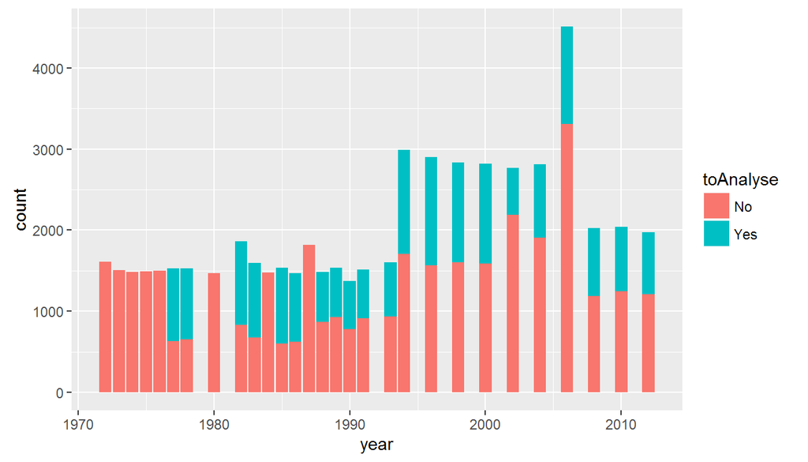

```r
 ggplot(gss_modified, aes(x= year, fill=toAnalyse)) + geom_bar()
```

```r
gss_modified_summarised <- gss_modified %>% group_by(year,sex,response,toAnalyse) %>% summarise(cnt = n())
```

There seems to be a clear difference between individuals who do not believe they will lose their job in the next 12 months and those who believe they will.

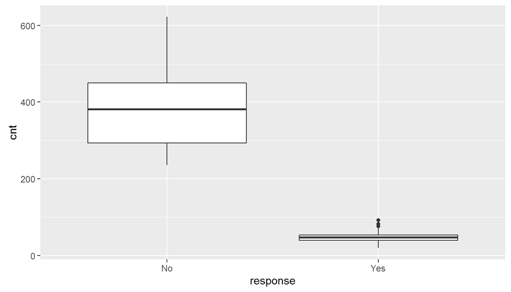

```r
ggplot(filter(gss_modified_summarised,toAnalyse == "Yes"), aes(x= response, y=cnt)) + geom_boxplot()
```

Here we start to get hints to our research questions. For males and females there is not clear difference in terms of believing that their job will be lost in the next 12 months

```r
gss_modified_summarised %>% filter(toAnalyse == "Yes") %>% group_by(sex) %>% summarise(mean = mean(cnt), iqr=IQR(cnt), median = median(cnt))
```

```
## # A tibble: 2 × 4
##      sex     mean    iqr median
##   <fctr>    <dbl>  <dbl>  <dbl>
## 1   Male 226.0476 361.75  164.0
## 2 Female 220.9048 316.75  172.5
```

```r
gss_modified_summarised %>% filter(toAnalyse == "Yes") %>% group_by(response) %>% summarise(mean = mean(cnt), iqr=IQR(cnt), median = median(cnt))
```

```
## # A tibble: 2 × 4
##   response      mean   iqr median
##      <chr>     <dbl> <dbl>  <dbl>
## 1       No 398.38095 157.0  382.0
## 2      Yes  48.57143  14.5   47.5
```

```r
gss_summarised_yes <- gss_modified_summarised %>% filter(toAnalyse == "Yes") %>% filter(response ==" Yes")
```

The following boxplot confirms that there does not seem to be a significant difference in belief about job security for males and females

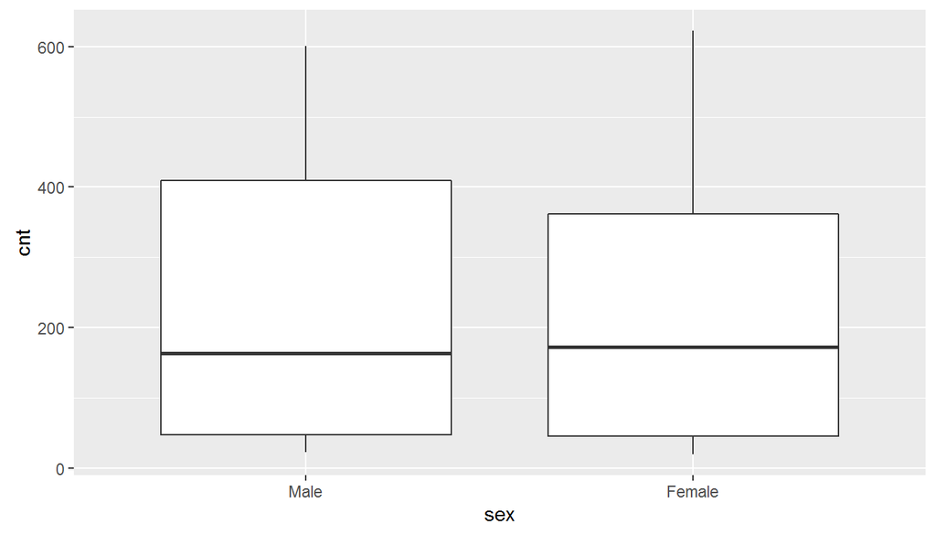

```r
ggplot(filter(gss_modified_summarised,toAnalyse == "Yes"), aes(x=sex, y=cnt)) + geom_boxplot()
```

## Inference

We more or less know the answer, however, let’s prove it using statistical inference.

```r
genderJobConfidenceSummary <- genderJobConfidence %>% group_by(sex) %>% summarise(gender_count = sum(count))
genderJobConfidenceFinal <- merge(genderJobConfidence, genderJobConfidenceSummary) %>% mutate(p = 100 * count/gender_count)

head(genderJobConfidenceFinal)
```

```
##      sex response count gender_count        p
## 1 Female       No  8277         9278 89.21104
## 2 Female      Yes  1001         9278 10.78896
## 3   Male       No  8455         9494 89.05625
## 4   Male      Yes  1039         9494 10.94375
```

Let’s now calculate *p-pool*

```r
p_pool <- (1039 + 1001) / (9278 + 9494)
print(p_pool)
```

```
## [1] 0.1086725
```

Let’s check conditions for inference of two proportions

independence:

- *Within groups: random sample and 10% condition*

Sampled males independent of each other, sampled females are as well

- *Between groups*

No reason to expect sampled males and females to be dependent

- *Sample size / skew*

### Hypothesis Test

$H_o: p_{male} - p_{female} = 0$

$H_a: p_{male} - p_{female} != 0$

Let’s calculate the Standard Error

```r
std_err <- sqrt(p_pool*(1-p_pool)/9494 + p_pool*(1-p_pool)/9278)
print(std_err)
```

```
## [1] 0.00454341
```

Let’s calculate the point estimate

```r
pdiff <- 0.1078 - 0.1094
print(pdiff)
```

```
## [1] -0.0016
```

```r
z <- pdiff / std_err
print(z)
```

```
## [1] -0.3521584
```

```r
p_value <- pnorm(z, lower.tail = FALSE) * 2
print(p_value)
```

```
## [1] 1.275281
```

```r
inference(y = response, x = sex, data = genderJobConfidence, statistic = "proportion", type = "ht", method = "theoretical", success = "Yes", alternative = "twosided", null = 0)
```

```
## Response variable: categorical (2 levels, success: Yes)
## Explanatory variable: categorical (2 levels)
## n_Male = 2, p_hat_Male = 0.5
## n_Female = 2, p_hat_Female = 0.5
## H0: p_Male =  p_Female
## HA: p_Male != p_Female
## z = 0
## p_value = 1
```

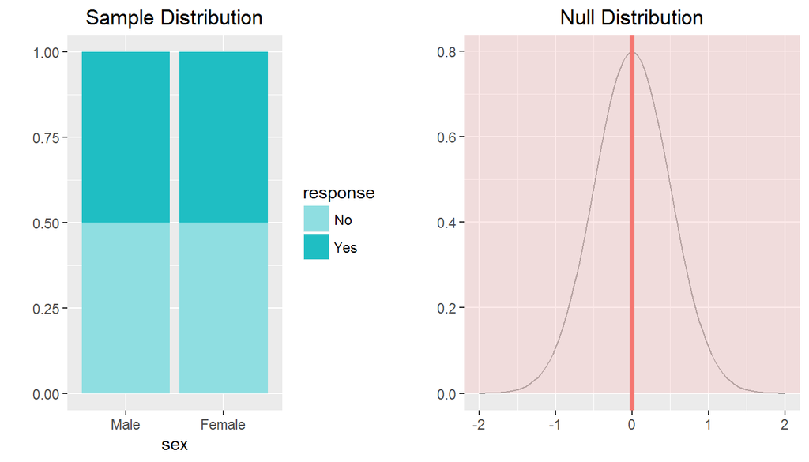

### As the p-value is over 0.05 We cannot reject the null hypothesis, which makes us conclude that there is not enough evidence of a statistical difference between males and females in terms of believing that they will lose their job in the next 12 months